# Inventory Monitoring at Distribution Centers

In this project we will be using deep learning to classify amazon bin images. We will classify the images with products upto 5 pieces.

This notebook has the code for preparing the dataset, training and deployment.

```python
# TODO: Install any packages that you might need
!pip install smdebug tqdm
!pip install torch torchvision --no-cache-dir
import requests
```

[output not shown]

```python
from PIL import Image
import io
```

```python
# TODO: Import any packages that you might need
import sagemaker
import boto3
import os
from sagemaker.pytorch import PyTorch
from sagemaker.session import Session
from sagemaker import get_execution_role
```

```
sagemaker.config INFO - Not applying SDK defaults from location: /etc/xdg/sagemaker/config.yaml
sagemaker.config INFO - Not applying SDK defaults from location: /home/ec2-user/.config/sagemaker/config.yaml
```

## Data Preparation

The cell below creates a folder called `train_data`, downloads training data and arranges it in subfolders. Each of these subfolders contain images where the number of objects is equal to the name of the folder. For instance, all images in folder `1` has images with 1 object in them. Images are not divided into training, testing or validation sets. If you feel like the number of samples are not enough, you can always download more data (instructions for that can be found [here](https://registry.opendata.aws/amazon-bin-imagery/)). However, we are not acessing you on the accuracy of your final trained model, but how you create your machine learning engineering pipeline.

```python
import os
import json
import boto3
from tqdm import tqdm

def download_and_arrange_data():
    s3_client = boto3.client('s3')

    with open('file_list.json', 'r') as f:
        d=json.load(f)

    for k, v in d.items():
        print(f"Downloading Images with {k} objects")
        directory=os.path.join('train_data', k)
        if not os.path.exists(directory):
            os.makedirs(directory)
        for file_path in tqdm(v):
            file_name=os.path.basename(file_path).split('.')[0]+'.jpg'
            s3_client.download_file('aft-vbi-pds', os.path.join('bin-images', file_name),
                             os.path.join(directory, file_name))

# download_and_arrange_data()
```

```python
download_and_arrange_data()
```

```
Downloading Images with 1 objects
```

```
Downloading Images with 2 objects
```

```
Downloading Images with 3 objects
```

```
Downloading Images with 4 objects
```

```
Downloading Images with 5 objects
```

## Dataset

[figure not shown]

```python
#TODO: Perform any data cleaning or data preprocessing
request_dict={ "url": "https://aft-vbi-pds.s3.amazonaws.com/bin-images/234.jpg" }
img_bytes = requests.get(request_dict['url']).content
Image.open(io.BytesIO(img_bytes))
```

```python
#Plot hist of distribution of number of products in bin image subset

import json
with open('file_list.json') as json_data:
    data = json.load(json_data)
dict = {}
for key, value in data.items():
    dict[key] = len(value)
dict
```

```
{'1': 1228, '2': 2299, '3': 2666, '4': 2373, '5': 1875}
```

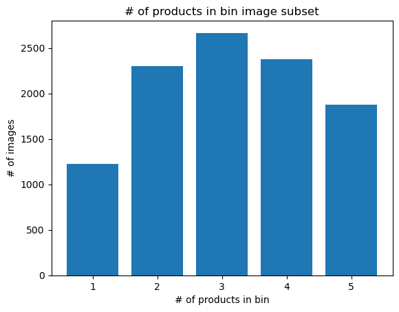

```python
import matplotlib.pyplot as plt

fig = plt.figure()
plt.bar(dict.keys(), dict.values())
plt.xlabel('# of products in bin')
plt.ylabel('# of images')
plt.title('# of products in bin image subset')
fig.savefig('bin_image_dist.png')
```

```python
#TODO: Upload the data to AWS S3
!aws s3 cp train_data s3://capstone-bin/data --recursive
```

[output not shown]

[output cut: 10386 more lines]

[output not shown]

```python
# Assign S3 paths for the training job
bucket = "capstone-bin"
data_path = "s3://{}/{}/".format(bucket, "data")
output_path = "s3://{}/{}/".format(bucket, "output")
model_path = "s3://{}/{}/".format(bucket, "model")

os.environ['SM_CHANNEL_TRAIN']= data_path
os.environ['SM_MODEL_DIR']= model_path
os.environ['SM_OUTPUT_DATA_DIR']= output_path
```

[output not shown]

## Model Training

**TODO:** This is the part where you can train a model. The type or architecture of the model you use is not important.

**Note:** You will need to use the `train.py` script to train your model.

```python
role = sagemaker.get_execution_role()
```

```
sagemaker.config INFO - Not applying SDK defaults from location: /etc/xdg/sagemaker/config.yaml
sagemaker.config INFO - Not applying SDK defaults from location: /home/ec2-user/.config/sagemaker/config.yaml
```

```python
#TODO: Declare your model training hyperparameter.
#NOTE: You do not need to do hyperparameter tuning. You can use fixed hyperparameter values
```

```python
#TODO: Create your training estimator
from sagemaker.pytorch import PyTorch

estimator = PyTorch(
    entry_point="hpo.py",
    base_job_name='bin-job-1',
    role=role,
    py_version='py3',
    framework_version="1.4.0",
    instance_count=1,
    instance_type="ml.g4dn.xlarge"
)
```

```
sagemaker.config INFO - Not applying SDK defaults from location: /etc/xdg/sagemaker/config.yaml
sagemaker.config INFO - Not applying SDK defaults from location: /home/ec2-user/.config/sagemaker/config.yaml
```

```python
# TODO: Fit your estimator
estimator.fit({"train": data_path}, wait=True)
```

```
INFO:sagemaker.image_uris:image_uri is not presented, retrieving image_uri based on instance_type, framework etc.
```

```
Using provided s3_resource
```

```
INFO:sagemaker:Creating training-job with name: bin-job-1-2023-11-04-16-17-04-038
```

[output not shown]

[output cut: 80 more lines]

```
Epoch 1, Phase valid
Accuracy: 18.00, Loss: 97.57, Best loss 93.10
RMSE: 1.4317821063276353
Testing the model.
Testing Model on Whole Testing Dataset

2023-11-04 16:23:38 Uploading - Uploading generated training modelTesting Loss: 96.47792582078414
Testing Accuracy: 18
RMSE: 1.3228756555322954
Saving the model.
2023-11-04 16:23:32,917 sagemaker-containers INFO     Reporting training SUCCESS

2023-11-04 16:23:49 Completed - Training job completed
Training seconds: 318
Billable seconds: 318
```

## Standout Suggestions

You do not need to perform the tasks below to finish your project. However, you can attempt these tasks to turn your project into a more advanced portfolio piece.

### Hyperparameter Tuning

**TODO:** Here you can perform hyperparameter tuning to increase the performance of your model. You are encouraged to

- tune as many hyperparameters as you can to get the best performance from your model
- explain why you chose to tune those particular hyperparameters and the ranges.

```python
#TODO: Create your hyperparameter search space
from sagemaker.tuner import (
    IntegerParameter,
    CategoricalParameter,
    ContinuousParameter,
    HyperparameterTuner,
)

hyperparameter_ranges = {
    "lr": ContinuousParameter(0.001, 0.1),
    "batch_size": CategoricalParameter([32, 64, 128, 256, 512]),
      "epochs": IntegerParameter(10,40)
}

objective_metric_name = "Test Loss"
objective_type = "Minimize"
metric_definitions = [{"Name": "Test Loss", "Regex": "Testing Loss: ([0-9\\.]+)"}]
```

```python
#TODO: Create your training estimator
#TODO: Create your training estimator
from sagemaker.pytorch import PyTorch

estimator = PyTorch(
    entry_point="hpo.py",
    base_job_name='bin-job-hpo-1',
    role=role,
    py_version='py3',
    framework_version="1.4.0",
    instance_count=1,
    instance_type="ml.g4dn.xlarge"
)
```

```
sagemaker.config INFO - Not applying SDK defaults from location: /etc/xdg/sagemaker/config.yaml
sagemaker.config INFO - Not applying SDK defaults from location: /home/ec2-user/.config/sagemaker/config.yaml
```

```python
tuner = HyperparameterTuner(
    estimator,
    objective_metric_name,
    hyperparameter_ranges,
    metric_definitions,
    max_jobs=2,
    max_parallel_jobs=2,
    objective_type=objective_type
)
```

```python
# TODO: Fit your estimator
tuner.fit({"train": data_path}, wait=True)
```

```
INFO:sagemaker.image_uris:image_uri is not presented, retrieving image_uri based on instance_type, framework etc.
WARNING:sagemaker.estimator:No finished training job found associated with this estimator. Please make sure this estimator is only used for building workflow config
WARNING:sagemaker.estimator:No finished training job found associated with this estimator. Please make sure this estimator is only used for building workflow config
INFO:sagemaker.image_uris:image_uri is not presented, retrieving image_uri based on instance_type, framework etc.
```

```
Using provided s3_resource
```

```
INFO:sagemaker:Creating hyperparameter tuning job with name: pytorch-training-231104-1701
```

```
................................................................................................................................................!
```

```python
# TODO: Find the best hyperparameters
best_estimator = tuner.best_estimator() #TODO

#Get the hyperparameters of the best trained model
best_estimator_hpo = best_estimator.hyperparameters()
print(best_estimator_hpo)
```

```
2023-11-04 17:09:55 Starting - Preparing the instances for training
2023-11-04 17:09:55 Downloading - Downloading input data
2023-11-04 17:09:55 Training - Training image download completed. Training in progress.
2023-11-04 17:09:55 Uploading - Uploading generated training model
2023-11-04 17:09:55 Completed - Resource retained for reuse
{'_tuning_objective_metric': '"Test Loss"', 'batch_size': '"32"', 'epochs': '30', 'lr': '0.025074731220441404', 'sagemaker_container_log_level': '20', 'sagemaker_estimator_class_name': '"PyTorch"', 'sagemaker_estimator_module': '"sagemaker.pytorch.estimator"', 'sagemaker_job_name': '"bin-job-hpo-1-2…
```

```python
# Creating the hyperparameters dictionary
hyperparameters = {
    "batch_size": best_estimator_hpo['batch_size'].strip('"'),
    "lr": best_estimator_hpo['lr'],
    "epochs": best_estimator_hpo['epochs'].strip('"')
}

print(hyperparameters)
```

```
{'batch_size': '32', 'lr': '0.025074731220441404', 'epochs': '30'}
```

### Model Profiling and Debugging

**TODO:** Use model debugging and profiling to better monitor and debug your model training job.

```python
from sagemaker.debugger import DebuggerHookConfig, ProfilerConfig, FrameworkProfile, CollectionConfig


#Set up debugging and profiling rules and hooks
rules = [
    Rule.sagemaker(rule_configs.vanishing_gradient()),
    Rule.sagemaker(rule_configs.overfit()),
    Rule.sagemaker(rule_configs.overtraining()),
    Rule.sagemaker(rule_configs.poor_weight_initialization()),
    Rule.sagemaker(rule_configs.loss_not_decreasing()),
    ProfilerRule.sagemaker(rule_configs.LowGPUUtilization()),
    ProfilerRule.sagemaker(rule_configs.ProfilerReport()),
]

debugger_config = DebuggerHookConfig(
    hook_parameters = {"train.save_interval": "10", "eval.save_interval": "5"},
    collection_configs = [CollectionConfig(name = "CrossEntropyLoss_output_0",
                                           parameters = {
                                               "include_regex": "CrossEntropyLoss_output_0",
                                               "train.save_interval": "10",
                                               "eval.save_interval": "1"})]
)

profiler_config = ProfilerConfig(
    system_monitor_interval_millis=500,
    framework_profile_params=FrameworkProfile(num_steps=10)
)
```

```
WARNING:sagemaker.deprecations:Framework profiling will be deprecated from tensorflow 2.12 and pytorch 2.0 in sagemaker>=2.
See: https://sagemaker.readthedocs.io/en/stable/v2.html for details.
```

```python
# TODO: Create and fit an estimator
estimator_db = PyTorch(
    entry_point="train.py",
    base_job_name="bin-model-debugging",
    role=role,
    instance_count=1,
    instance_type="ml.g4dn.xlarge",
    hyperparameters=hyperparameters,
    framework_version="1.8",
    py_version="py36",
    ## Debugger parameters
    rules=rules,
    debugger_hook_config=debugger_config,
    profiler_config=profiler_config
)
```

```
sagemaker.config INFO - Not applying SDK defaults from location: /etc/xdg/sagemaker/config.yaml
sagemaker.config INFO - Not applying SDK defaults from location: /home/ec2-user/.config/sagemaker/config.yaml
```

```python
# TODO: Plot a debugging output.
estimator_db.fit({"train": data_path}, wait=True)
```

```
INFO:sagemaker.image_uris:image_uri is not presented, retrieving image_uri based on instance_type, framework etc.
INFO:sagemaker:Creating training-job with name: bin-model-debugging-2023-11-04-17-32-23-280
```

[output not shown]

[output cut: 167 more lines]

```
LossNotDecreasing: InProgress

2023-11-04 17:44:34 Uploading - Uploading generated training modelLowGPUUtilization: IssuesFound
ProfilerReport: InProgress

2023-11-04 17:45:02 Completed - Training job completed
VanishingGradient: NoIssuesFound
Overfit: NoIssuesFound
Overtraining: NoIssuesFound
PoorWeightInitialization: IssuesFound
LossNotDecreasing: NoIssuesFound
LowGPUUtilization: IssuesFound
ProfilerReport: IssuesFound
Training seconds: 649
Billable seconds: 649
```

```python
job_name = estimator_db.latest_training_job.name
client = estimator_db.sagemaker_session.sagemaker_client
description = client.describe_training_job(TrainingJobName=estimator_db.latest_training_job.name)

print(job_name)
```

```
bin-model-debugging-2023-11-04-17-32-23-280
```

```python
from smdebug.trials import create_trial
from smdebug.core.modes import ModeKeys

trial = create_trial(estimator_db.latest_job_debugger_artifacts_path())
print(trial.tensor_names())
print(len(trial.tensor("CrossEntropyLoss_output_0").steps(mode=ModeKeys.TRAIN)))
print(len(trial.tensor("CrossEntropyLoss_output_0").steps(mode=ModeKeys.EVAL)))
```

```
[2023-11-04 17:47:48.252 ip-172-16-65-230.ec2.internal:9435 INFO utils.py:28] RULE_JOB_STOP_SIGNAL_FILENAME: None
[2023-11-04 17:47:48.294 ip-172-16-65-230.ec2.internal:9435 INFO s3_trial.py:42] Loading trial debug-output at path s3://sagemaker-us-east-1-327427809917/bin-model-debugging-2023-11-04-17-32-23-280/debug-output
[2023-11-04 17:47:48.724 ip-172-16-65-230.ec2.internal:9435 WARNING s3handler.py:184] Encountered the exception An error occurred while reading from response stream: ('Connection broken: IncompleteRead(0 bytes read, 232 more expected)', IncompleteRead(0 bytes read, 232 more expected)) while reading …
[2023-11-04 17:47:52.046 ip-172-16-65-230.ec2.internal:9435 INFO trial.py:197] Training has ended, will refresh one final time in 1 sec.
[2023-11-04 17:47:53.064 ip-172-16-65-230.ec2.internal:9435 INFO trial.py:210] Loaded all steps
['CrossEntropyLoss_output_0', 'gradient/ResNet_fc.0.bias', 'gradient/ResNet_fc.0.weight', 'gradient/ResNet_fc.2.bias', 'gradient/ResNet_fc.2.weight', 'layer1.0.relu_input_0', 'layer1.0.relu_input_1', 'layer1.0.relu_input_2', 'layer1.1.relu_input_0', 'layer1.1.relu_input_1', 'layer1.1.relu_input_2', …
59
264
```

```python
#Code from debugging class
def get_data(trial, tname, mode):
    tensor = trial.tensor(tname)
    steps = tensor.steps(mode=mode)
    vals = []
    for s in steps:
        vals.append(tensor.value(s, mode=mode))
    return steps, vals
```

```python
#Code from debugging class
import matplotlib.pyplot as plt
from mpl_toolkits.axes_grid1 import host_subplot


def plot_tensor(trial, tensor_name):

    steps_train, vals_train = get_data(trial, tensor_name, mode=ModeKeys.TRAIN)
    print("loaded TRAIN data")
    steps_eval, vals_eval = get_data(trial, tensor_name, mode=ModeKeys.EVAL)
    print("loaded EVAL data")

    fig = plt.figure(figsize=(10, 7))
    host = host_subplot(111)

    par = host.twiny()

    host.set_xlabel("Steps (TRAIN)")
    par.set_xlabel("Steps (EVAL)")
    host.set_ylabel(tensor_name)

    (p1,) = host.plot(steps_train, vals_train, label=tensor_name)
    print("completed TRAIN plot")
    (p2,) = par.plot(steps_eval, vals_eval, label="val_" + tensor_name)
    print("completed EVAL plot")
    leg = plt.legend()

    host.xaxis.get_label().set_color(p1.get_color())
    leg.texts[0].set_color(p1.get_color())

    par.xaxis.get_label().set_color(p2.get_color())
    leg.texts[1].set_color(p2.get_color())

    plt.ylabel(tensor_name)

    plt.show()

    fig.savefig('CrossEntropyLoss_0_tensor.png')  #added
```

[output not shown]

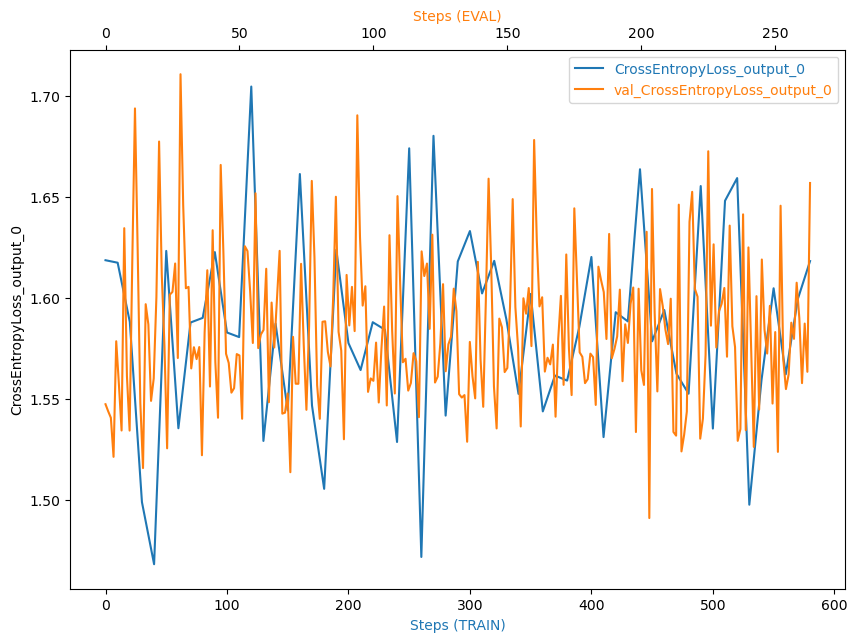

```python
plot_tensor(trial, "CrossEntropyLoss_output_0")
```

```python
# Display the profiler output
rule_output_path = estimator_db.output_path + estimator_db.latest_training_job.job_name + "/rule-output"
rule_output_path
```

```
's3://sagemaker-us-east-1-327427809917/bin-model-debugging-2023-11-04-17-32-23-280/rule-output'
```

```python
! aws s3 ls {rule_output_path} --recursive
```

```
2023-11-04 17:44:46     414847 bin-model-debugging-2023-11-04-17-32-23-280/rule-output/ProfilerReport/profiler-output/profiler-report.html
2023-11-04 17:44:45     269476 bin-model-debugging-2023-11-04-17-32-23-280/rule-output/ProfilerReport/profiler-output/profiler-report.ipynb
2023-11-04 17:44:41        192 bin-model-debugging-2023-11-04-17-32-23-280/rule-output/ProfilerReport/profiler-output/profiler-reports/BatchSize.json
2023-11-04 17:44:41       6081 bin-model-debugging-2023-11-04-17-32-23-280/rule-output/ProfilerReport/profiler-output/profiler-reports/CPUBottleneck.json
2023-11-04 17:44:41       1794 bin-model-debugging-2023-11-04-17-32-23-280/rule-output/ProfilerReport/profiler-output/profiler-reports/Dataloader.json
2023-11-04 17:44:41        325 bin-model-debugging-2023-11-04-17-32-23-280/rule-output/ProfilerReport/profiler-output/profiler-reports/GPUMemoryIncrease.json
2023-11-04 17:44:41       1770 bin-model-debugging-2023-11-04-17-32-23-280/rule-output/ProfilerReport/profiler-output/profiler-reports/IOBottleneck.json
2023-11-04 17:44:41        327 bin-model-debugging-2023-11-04-17-32-23-280/rule-output/ProfilerReport/profiler-output/profiler-reports/LoadBalancing.json
2023-11-04 17:44:41        336 bin-model-debugging-2023-11-04-17-32-23-280/rule-output/ProfilerReport/profiler-output/profiler-reports/LowGPUUtilization.json
2023-11-04 17:44:41        231 bin-model-debugging-2023-11-04-17-32-23-280/rule-output/ProfilerReport/profiler-output/profiler-reports/MaxInitializationTime.json
2023-11-04 17:44:41       1673 bin-model-debugging-2023-11-04-17-32-23-280/rule-output/ProfilerReport/profiler-output/profiler-reports/OverallFrameworkMetrics.json
2023-11-04 17:44:41        613 bin-model-debugging-2023-11-04-17-32-23-280/rule-output/ProfilerReport/profiler-output/profiler-reports/OverallSystemUsage.json
2023-11-04 17:44:41       2263 bin-model-debugging-2023-11-04-17-32-23-280/rule-output/ProfilerReport/profiler-output/profiler-reports/StepOutlier.json
```

```python
! aws s3 cp {rule_output_path} ./ --recursive
```

[output not shown]

```python
import os

# get the autogenerated folder name of profiler report
profiler_report_name = [
    rule["RuleConfigurationName"]
    for rule in estimator_db.latest_training_job.rule_job_summary()
    if "Profiler" in rule["RuleConfigurationName"]
][0]
```

```python
import IPython

rule_output_path = estimator_db.output_path + estimator_db.latest_training_job.job_name + "/rule-output"
print(f"You will find the profiler report in {rule_output_path}")

! aws s3 ls {rule_output_path} --recursive
! aws s3 cp {rule_output_path} ./ --recursive

# get the autogenerated folder name of profiler report
profiler_report_name = [
    rule["RuleConfigurationName"]
    for rule in estimator_db.latest_training_job.rule_job_summary()
    if "Profiler" in rule["RuleConfigurationName"]
][0]


IPython.display.HTML(filename=profiler_report_name + "/profiler-output/profiler-report.html")
```

[output not shown]

SageMaker Debugger Profiling Report

SageMaker Debugger auto generated this report. You can generate similar reports on all supported training jobs. The report provides summary of training job, system resource usage statistics, framework metrics, rules summary, and detailed analysis from each rule. The graphs and tables are interactive.

**Legal disclaimer:** This report and any recommendations are provided for informational purposes only and are not definitive. You are responsible for making your own independent assessment of the information.

```
# Parameters
processing_job_arn = "arn:aws:sagemaker:us-east-1:327427809917:processing-job/bin-model-debugging-2023-1-ProfilerReport-e760cba9"
```

Training job summary

[interactive chart not shown]

System usage statistics

[interactive chart not shown]

Framework metrics summary

[interactive chart not shown]

Overview: CPU operators

[interactive chart not shown]

Overview: GPU operators

[interactive chart not shown]

Rules summary

The following table shows a profiling summary of the Debugger built-in rules. The table is sorted by the rules that triggered the most frequently. During your training job, the GPUMemoryIncrease rule was the most frequently triggered. It processed 1215 datapoints and was triggered 4 times.

|  | Description | Recommendation | Number of times rule triggered | Number of datapoints | Rule parameters |
| --- | --- | --- | --- | --- | --- |
| GPUMemoryIncrease | Measures the average GPU memory footprint and triggers if there is a large increase. | Choose a larger instance type with more memory if footprint is close to maximum available memory. | 4 | 1215 | increase:5 patience:1000 window:10 |
| LowGPUUtilization | Checks if the GPU utilization is low or fluctuating. This can happen due to bottlenecks, blocking calls for synchronizations, or a small batch size. | Check if there are bottlenecks, minimize blocking calls, change distributed training strategy, or increase the batch size. | 2 | 1215 | threshold_p95:70 threshold_p5:10 window:500 patience:1000 |
| IOBottleneck | Checks if the data I/O wait time is high and the GPU utilization is low. It might indicate IO bottlenecks where GPU is waiting for data to arrive from storage. The rule evaluates the I/O and GPU utili… | Pre-fetch data or choose different file formats, such as binary formats that improve I/O performance. | 0 | 1220 | threshold:50 io_threshold:50 gpu_threshold:10 patience:1000 |
| LoadBalancing | Detects workload balancing issues across GPUs. Workload imbalance can occur in training jobs with data parallelism. The gradients are accumulated on a primary GPU, and this GPU might be overused with … | Choose a different distributed training strategy or a different distributed training framework. | 0 | 1215 | threshold:0.2 patience:1000 |
| BatchSize | Checks if GPUs are underutilized because the batch size is too small. To detect this problem, the rule analyzes the average GPU memory footprint, the CPU and the GPU utilization. | The batch size is too small, and GPUs are underutilized. Consider running on a smaller instance type or increasing the batch size. | 0 | 1214 | cpu_threshold_p95:70 gpu_threshold_p95:70 gpu_memory_threshold_p95:70 patience:1000 window:500 |
| CPUBottleneck | Checks if the CPU utilization is high and the GPU utilization is low. It might indicate CPU bottlenecks, where the GPUs are waiting for data to arrive from the CPUs. The rule evaluates the CPU and GPU… | Consider increasing the number of data loaders or applying data pre-fetching. | 0 | 1220 | threshold:50 cpu_threshold:90 gpu_threshold:10 patience:1000 |
| StepOutlier | Detects outliers in step duration. The step duration for forward and backward pass should be roughly the same throughout the training. If there are significant outliers, it may indicate a system stall… | Check if there are any bottlenecks (CPU, I/O) correlated to the step outliers. | 0 | 853 | threshold:3 mode:None n_outliers:10 stddev:3 |
| Dataloader | Checks how many data loaders are running in parallel and whether the total number is equal the number of available CPU cores. The rule triggers if number is much smaller or larger than the number of a… | Change the number of data loader processes. | 0 | 10 | min_threshold:70 max_threshold:200 |
| MaxInitializationTime | Checks if the time spent on initialization exceeds a threshold percent of the total training time. The rule waits until the first step of training loop starts. The initialization can take longer if do… | Initialization takes too long. If using File mode, consider switching to Pipe mode in case you are using TensorFlow framework. | 0 | 853 | threshold:20 |

Analyzing the training loop

Step duration analysis

[interactive chart not shown]

**Step durations on node algo-1-27:**

The following table is a summary of the statistics of step durations measured on node algo-1-27. The rule has analyzed the step duration from Step:ModeKeys.EVAL phase. The average step duration on node algo-1-27 was 0.04s. The rule detected 1 outliers, where step duration was larger than 3 times the standard deviation of 0.23s

|  | mean | max | p99 | p95 | p50 | min |
| --- | --- | --- | --- | --- | --- | --- |
| Step Durations in [s] | 0.04 | 3.73 | 0.04 | 0.03 | 0.03 | 0.02 |

The following histogram shows the step durations measured on the different nodes. You can turn on or turn off the visualization of histograms by selecting or unselecting the labels in the legend.

[interactive chart not shown]

GPU utilization analysis

**Usage per GPU**

[interactive chart not shown]

**GPU utilization of gpu0 on node algo-1:**

[interactive chart not shown]

**Workload balancing**

[interactive chart not shown]

Dataloading analysis

[interactive chart not shown]

Batch size

[interactive chart not shown]

CPU bottlenecks

[interactive chart not shown]

I/O bottlenecks

[interactive chart not shown]

GPU memory

[interactive chart not shown]

**Memory utilization of gpu0 on node algo-1:**

[interactive chart not shown]

[figure not shown]

### Model Deploying and Querying

**TODO:** Can you deploy your model to an endpoint and then query that endpoint to get a result?

```python
# TODO: Deploy your model to an endpoint
model_location=estimator_db.model_data
print(model_location)
```

```
s3://sagemaker-us-east-1-327427809917/bin-model-debugging-2023-11-04-17-32-23-280/output/model.tar.gz
```

```python
# TODO: Run an prediction on the endpoint
import sagemaker
import boto3
from sagemaker.tuner import CategoricalParameter, ContinuousParameter, HyperparameterTuner
from sagemaker.pytorch import PyTorch
from sagemaker import get_execution_role

from sagemaker.pytorch import PyTorchModel
from sagemaker.predictor import Predictor

role = get_execution_role()
```

```
sagemaker.config INFO - Not applying SDK defaults from location: /etc/xdg/sagemaker/config.yaml
sagemaker.config INFO - Not applying SDK defaults from location: /home/ec2-user/.config/sagemaker/config.yaml
```

```python
jpeg_serializer = sagemaker.serializers.IdentitySerializer("image/jpeg")
json_deserializer = sagemaker.deserializers.JSONDeserializer()


class ImagePredictor(Predictor):
    def __init__(self, endpoint_name, sagemaker_session):
        super(ImagePredictor, self).__init__(
            endpoint_name,
            sagemaker_session=sagemaker_session,
            serializer=jpeg_serializer,
            deserializer=json_deserializer,
        )
```

```python
pytorch_model = PyTorchModel(model_data=model_location,
                             role=role,
                             entry_point='inference.py',
                             py_version='py36',
                             framework_version='1.8',
                             predictor_cls=ImagePredictor)
```

```
sagemaker.config INFO - Not applying SDK defaults from location: /etc/xdg/sagemaker/config.yaml
sagemaker.config INFO - Not applying SDK defaults from location: /home/ec2-user/.config/sagemaker/config.yaml
```

```python
predictor = pytorch_model.deploy(initial_instance_count=1, instance_type='ml.m5.large')
```

```
sagemaker.config INFO - Not applying SDK defaults from location: /etc/xdg/sagemaker/config.yaml
sagemaker.config INFO - Not applying SDK defaults from location: /home/ec2-user/.config/sagemaker/config.yaml
```

```
INFO:sagemaker:Repacking model artifact (s3://sagemaker-us-east-1-327427809917/bin-model-debugging-2023-11-04-17-32-23-280/output/model.tar.gz), script artifact (None), and dependencies ([]) into single tar.gz file located at s3://sagemaker-us-east-1-327427809917/pytorch-inference-2023-11-04-18-00-2…
INFO:sagemaker:Creating model with name: pytorch-inference-2023-11-04-18-00-31-344
INFO:sagemaker:Creating endpoint-config with name pytorch-inference-2023-11-04-18-00-32-040
INFO:sagemaker:Creating endpoint with name pytorch-inference-2023-11-04-18-00-32-040
```

```
-----!
```

```python
import requests

request_dict={ "url": "https://aft-vbi-pds.s3.amazonaws.com/bin-images/322.jpg" }

img_bytes = requests.get(request_dict['url']).content
type(img_bytes)
```

```
bytes
```

[figure not shown]

```python
from PIL import Image
import io
Image.open(io.BytesIO(img_bytes))
```

```python
response=predictor.predict(img_bytes, initial_args={"ContentType": "image/jpeg"})
```

```python
response
```

```
[[-0.3417279124259949,
  0.22165267169475555,
  0.32626551389694214,
  0.14200721681118011,
  -0.04346131160855293]]
```

```python
import numpy as np
np.argmax(response, 1)
```

```
array([2])
```

```python
import requests

request_dict={ "url": "https://aft-vbi-pds.s3.amazonaws.com/bin-images/767.jpg" }

img_bytes = requests.get(request_dict['url']).content
type(img_bytes)
```

```
bytes
```

[figure not shown]

```python
from PIL import Image
import io
Image.open(io.BytesIO(img_bytes))
```

```python
response=predictor.predict(img_bytes, initial_args={"ContentType": "image/jpeg"})
```

```python
response
```

```
[[-0.3417279124259949,
  0.22165267169475555,
  0.32626551389694214,
  0.14200721681118011,
  -0.04346131160855293]]
```

```python
import numpy as np
np.argmax(response, 1)
```

```
array([2])
```

```python
# TODO: Remember to shutdown/delete your endpoint once your work is done
predictor.delete_endpoint()
```

```
INFO:sagemaker:Deleting endpoint configuration with name: pytorch-inference-2023-11-04-18-00-32-040
INFO:sagemaker:Deleting endpoint with name: pytorch-inference-2023-11-04-18-00-32-040
```

### Multi-Instance Training

**TODO:** Can you train your model on multiple instances?

```python
# TODO: Train your model on Multiple Instances
hyperparameters = {'batch_size': 32, 'lr': '0.025074731220441404','epochs': 30}

estimator = PyTorch(
    entry_point='train.py',
    base_job_name='capstone-multi-inst',
    role=role,
    instance_count=2,
    instance_type='ml.g4dn.xlarge' ,
    framework_version='1.4.0',
    py_version='py3',
    hyperparameters=hyperparameters,
)

estimator.fit({"train": data_path}, wait=True)
```

```
sagemaker.config INFO - Not applying SDK defaults from location: /etc/xdg/sagemaker/config.yaml
sagemaker.config INFO - Not applying SDK defaults from location: /home/ec2-user/.config/sagemaker/config.yaml
```

```
INFO:sagemaker.image_uris:image_uri is not presented, retrieving image_uri based on instance_type, framework etc.
INFO:sagemaker:Creating training-job with name: capstone-multi-inst-2023-11-04-18-06-03-073
```

[output not shown]

[output cut: 239 more lines]

```
Testing Loss: 49.768331946748674
Testing Accuracy: 8
RMSE: 1.4142135623730951
Saving the model.
2023-11-04 18:13:45,603 sagemaker-containers INFO     Reporting training SUCCESS
Testing Loss: 49.95535513848969
Testing Accuracy: 7
RMSE: 1.3228756555322954
Saving the model.
2023-11-04 18:13:50,955 sagemaker-containers INFO     Reporting training SUCCESS

2023-11-04 18:14:14 Uploading - Uploading generated training model
2023-11-04 18:14:14 Completed - Training job completed
Training seconds: 806
Billable seconds: 806
```